# Support Vector Machines and Flexible Discriminants:

Here we will talk about support vector machine, which produces nonlinear boundaries by constructing a linear boundary in a large, transformed version of the feature space.

### The Support Vector Classifier:

We know how to construct optimal separating hyperplance between two perfectly seperated classes. We review this and generalize to the nonseparable case, where the classes may not be separabale by linear boundary.

[figure not shown]

By bounding the sum we actually bound the total proportional amount by which predictions fall on the wrong side of their margin.

#### Example:

We will use mixture example here from the ESL book to illustrate the concept of support vector classifier.

```python
import numpy as np
from matplotlib import pyplot as plt

%matplotlib inline

# numpy produces many warnings, we don't need them here
np.warnings.filterwarnings('ignore')

# define commonly used colors
GRAY1, GRAY4, PURPLE = '#231F20', '#646369', '#A020F0'
BLUE, ORANGE, BLUE1 = '#57B5E8', '#E69E00', '#174A7E'

# configure all plots font family and border line widths
plt.rcParams['font.family'] = 'Arial'
plt.rcParams['axes.linewidth'] = 0.5
```

```python
cd C:\Machine Learning\Datasets
```

```
C:\Machine Learning\Datasets
```

```python
from sklearn.mixture import GaussianMixture
from sklearn.metrics import accuracy_score
from sklearn.mixture.gaussian_mixture import _compute_precision_cholesky
import pandas as pd
```

```python
# load training data that was used in the book
df = pd.read_csv("mixture.txt")
X_train = df[['x1', 'x2']].values
y_train = df.y.values

# set the known BLUE and ORANGE clusters means
blue_means = np.array([[-0.25343316, 1.7414788], [0.26669318, 0.3712341],
                       [2.09646921, 1.2333642], [-0.06127272, -0.2086791],
                       [2.70354085, 0.5968283], [2.37721198, -1.1864147],
                       [1.05690759, -0.6838939], [0.57888354, -0.0683458],
                       [0.62425213, 0.5987384], [1.67335495, -0.2893159]])
orange_means = np.array([[1.19936869, 0.2484086], [-0.30256110, 0.9454190],
                         [0.05727232, 2.4197271], [1.32932203, 0.8192260],
                         [-0.07938424, 1.6138017], [3.50792673, 1.0529863],
                         [1.61392290, 0.6717378], [1.00753570, 1.3683071],
                         [-0.45462141, 1.0860697], [-1.79801805, 1.9297806]])
all_means = np.vstack((blue_means, orange_means))
```

```python
# even though we already know means and covariances, we need to
# do "fake fit", otherwise GaussianMixture model will not work
gaussian_mixture_model = GaussianMixture(
    n_components=20,
    covariance_type='spherical',
    means_init=all_means,
    random_state=1
).fit(all_means)
# set known covariances
gaussian_mixture_model.covariances_ = [1/5]*20
# it looks like a hack, but GaussianMixture uses precisions_cholesky_
# for predict_proba method. Because we changed covariances_ we need
# to recalculate precisions_cholesky_ too.
gaussian_mixture_model.precisions_cholesky_ = _compute_precision_cholesky(
    gaussian_mixture_model.covariances_,
    gaussian_mixture_model.covariance_type)
```

```python
# sample 10,000 points for testing
X_test, y_test = gaussian_mixture_model.sample(10000)
# y_test contains sampled component indices
# index < 10 means that the class is BLUE (0)
y_test = 1*(y_test >= 10)
```

```python
#Optimal Bayes:
def optimal_bayes_predict(X):
    components_proba = gaussian_mixture_model.predict_proba(X)
    # first 10 components are BLUE(0), and others are BROWN(1)
    blue_proba = np.sum(components_proba[:, :10], axis=1)
    brown_proba = np.sum(components_proba[:, 10:], axis=1)
    y_hat = 1*(blue_proba < brown_proba)
    return y_hat
```

```python
bayes_error_rate = 1 - accuracy_score(y_test, optimal_bayes_predict(X_test))
print(f'The optimal Bayes error rate = {bayes_error_rate}')
```

```
The optimal Bayes error rate = 0.2148
```

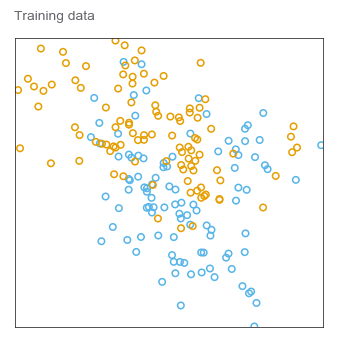

```python
# prepares a plot with a title and circles representing training data
def plot_train_data(title):
    fig, ax = plt.subplots(figsize=(2.8, 2.8), dpi=110)
    ax.set_aspect(1.3)
    ax.scatter(X_train[:, 0], X_train[:, 1], s=18, facecolors='none',
               edgecolors=np.array([BLUE, ORANGE])[y_train])
    ax.tick_params(
        bottom=False, left=False, labelleft=False, labelbottom=False)
    ax.set_xlim(-2.6, 4.2)
    ax.set_ylim(-2.0, 2.9)
    fig.subplots_adjust(left=0, right=1, top=1, bottom=0)
    ax.text(-2.6, 3.2, title, color=GRAY4, fontsize=9)
    for spine in ax.spines.values():
        spine.set_color(GRAY1)
    return fig, ax

# test it
_, _ = plot_train_data('Training data')
```

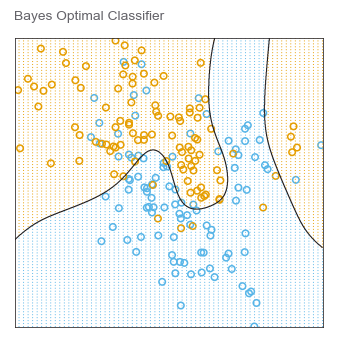

```python
# given a model prediction function computes X points on n x n grid and the
# corresponding predicted classes
def fill_prediction_grid(n1, n2, predict):
    x1, x2 = np.linspace(-2.6, 4.2, n1), np.linspace(-2.0, 2.9, n2)
    X = np.transpose([np.tile(x1, n2), np.repeat(x2, n1)])
    y = predict(X)
    return X, y


# given a model prediction function computes X0 and X1 n x n meshgrids
# and the corresponing predicted classes meshgrid
def fill_prediction_meshgrid(predict):
    n1, n2 = 1000, 1000
    X, y = fill_prediction_grid(n1, n2, predict)
    return X[:, 0].reshape(n1, n2), X[:, 1].reshape(n1, n2), y.reshape(n1, n2)


# given a model prediction function plots train data, model decision
# bounary and background dots
def plot_model(predict, title):
    fig, ax = plot_train_data(title)
    # plot background dots
    X, y = fill_prediction_grid(69, 99, predict)
    ax.scatter(X[:, 0], X[:, 1], marker='.', lw=0, s=2,
               c=np.array([BLUE, ORANGE])[y])
    # plot the decision boundary
    X0, X1, Y = fill_prediction_meshgrid(predict)
    ax.contour(X0, X1, Y, [0.5], colors=GRAY1, linewidths=[0.7])
    return fig, ax

# plot the optimal Bayes decision boundary
_, _ = plot_model(optimal_bayes_predict, 'Bayes Optimal Classifier')
```

```python
# lets save Bayes meshgrids for optimal decision boundary plotting
X0_bayes, X1_bayes, Y_bayes = fill_prediction_meshgrid(optimal_bayes_predict)


# given a model prediction function plots performance statistics
def plot_model_stat(predict, title):
    fig, ax = plot_model(predict, title)
    ax.contour(X0_bayes, X1_bayes, Y_bayes, [0.5], colors='purple',
               linewidths=[0.5], linestyles='dashed')
    test_error_rate = 1 - accuracy_score(y_test, predict(X_test))
    train_error_rate = 1 - accuracy_score(y_train, predict(X_train))
    parms = {'color': GRAY1, 'fontsize': 7,
             'bbox': {'facecolor': 'white', 'pad': 3, 'edgecolor': 'none'}}
    ax.text(-2.42, -1.35, f'Training Error: {train_error_rate:.3f}', **parms)
    ax.text(-2.42, -1.62, f'Test Error:       {test_error_rate:.3f}', **parms)
    ax.text(-2.42, -1.89, f'Bayes Error:    {bayes_error_rate:.3f}', **parms)
    return fig, ax
```

```python
from sklearn.svm import SVC
```

```python
# plots support vector machine model information, margins and
# small black points for observations that lay on the margin.
def plot_svc_model(svc, title):
    sv = abs(svc.decision_function(svc.support_vectors_))
    v = svc.support_vectors_[(sv > 0.99) & (sv < 1.01)]
    fig, ax = plot_model_stat(svc.predict, title)
    X0, X1, Y = fill_prediction_meshgrid(svc.decision_function)
    ax.contour(X0, X1, Y, [-1, 1], colors=GRAY1, linewidths=[0.5, 0.5],
               linestyles='dashed')
    ax.scatter(v[:, 0], v[:, 1], c='black', s=10)
```

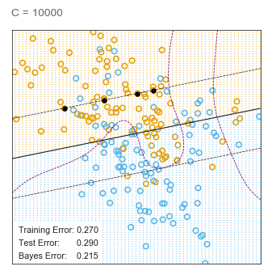

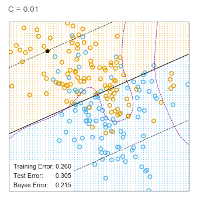

```python
#           The linear support vector boundary for the mixture data example
#           with two overlapping classes, for two different values of C.
#           The broken lines indicate the margins, where f(x) = ±1. The support
#           points (αi > 0) are all the points on the wrong side of their
#           margin.

linear_svc1 = SVC(
    C=10000, kernel='linear'
).fit(X_train, y_train)
plot_svc_model(linear_svc1, 'C = 10000')

# PAGE 422. In the upper panel 62% of the observations are support points,
#           while in the lower panel 85% are.
linear_svc2 = SVC(
    C=0.01, kernel='linear'
).fit(X_train, y_train)

# PAGE 421.  The margin is larger for C = 0.01 than it is for C = 10,000. Hence
#            larger values of C focus attention more on (correctly classiﬁed)
#            points near the decision boundary, while smaller values involve
#            data further away. Either way, misclassified points are given
#            weight, no matter how far away. In this example the procedure is
#            not very sensitive to choices of C, because of the rigidity of a
#            linear boundary.
plot_svc_model(linear_svc2, 'C = 0.01')
```

### Support Vector Machines and Kernels:

The support vector classifier described so far finds linear boundaries in the input feature space. As with other linear methods, we can make the procedure more flexible by enlarging the feature space using basis expansion such as polynomials or splines. Generally linear boundaries in the enlarged space achieve better training-class separation, and translate to non-linear boundaries in the original space.  
The support vector machine classifier is an extension of this idea, where the dimension of the enlarged space is allowed to get very large, infinite in some cases. It might seem that the computations would become prohibitive. It would also seem that with sufficient basis functions, the data would be separable, and overfitting would occur. But surprisingly there are neat algorithms that overcome all of these issues. For more on this check Elements of Statistical Learning.

#### SVM and Curse of Dimensionality:

It might seem that SVM has an edge on the curse of dimensionality, but here I will give an example when SVM fails horribly. Let's assume that p (number of features) is very large, but the class separation occured only in the linear subspace spanned by say $X_{1}$ and $X_{2}$, this kernel would not easily find the structure and would suffer from having many dimensions to search over. So I want to make it clear here SVM is in no way superior to all other methods. It has some positive sides but it also have some serious downsides.

##### Example:

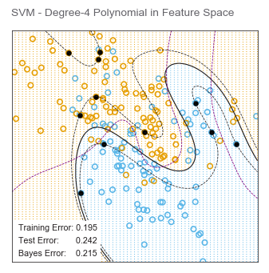

```python
poly_svc = SVC(
    kernel='poly', degree=4, coef0=7, C=10
).fit(X_train, y_train)
plot_svc_model(poly_svc, 'SVM - Degree-4 Polynomial in Feature Space')
```

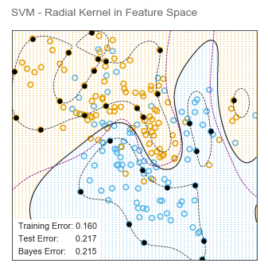

```python
rbf_svc = SVC(
    kernel='rbf', gamma=1
).fit(X_train, y_train)
plot_svc_model(rbf_svc, 'SVM - Radial Kernel in Feature Space')
```